# Did Covid change people’s perspective on what is important in a job

## Introduction

During the beginning of Covid, many white-collar working adults were forced to work away from the traditional office space that many were accustomed to. Many people invested time and money into creating their own office space in their homes. People are now slowly returning to a new way of life. We are seeing more people return to an office setting or companies telling their employees to return. .

## Why is this important to us?

As computer science students, we must learn how these office settings are affecting the everyday individual. We will all mostly work in an office setting so understanding how our future peers view their working environment is important for all of our futures.

## What is the study about?

Question asked: *“What is more important to you in a new job/career? (Regardless of salary)”*

Where I did the survey: Google Surveys https://surveys.google.com/.

Cost: 10-15 Cents a survey

Population: US, Western US, UK

Who can participate in the survey: app users that are linked to the AdMob network

Ended 04/19/2022

## Options in the survey

- *Working From Home*
- *Work Environment*
- *Work Location*
- *Job Satisfaction*
- *Employee Benefits*

## Example of Survey

[figure not shown]

Survey Example

## Example of Data Collected

```r
summary(USA_Survey)
```

```
##      Age               Gender             Region           Q1.Answer
##  Length:231         Length:231         Length:231         Length:231
##  Class :character   Class :character   Class :character   Class :character
##  Mode  :character   Mode  :character   Mode  :character   Mode  :character
##
##
##
##  Response.Count
##  Min.   :1.000
##  1st Qu.:1.000
##  Median :1.000
##  Mean   :1.091
##  3rd Qu.:1.000
##  Max.   :3.000
```

##### Data space

## UK Results

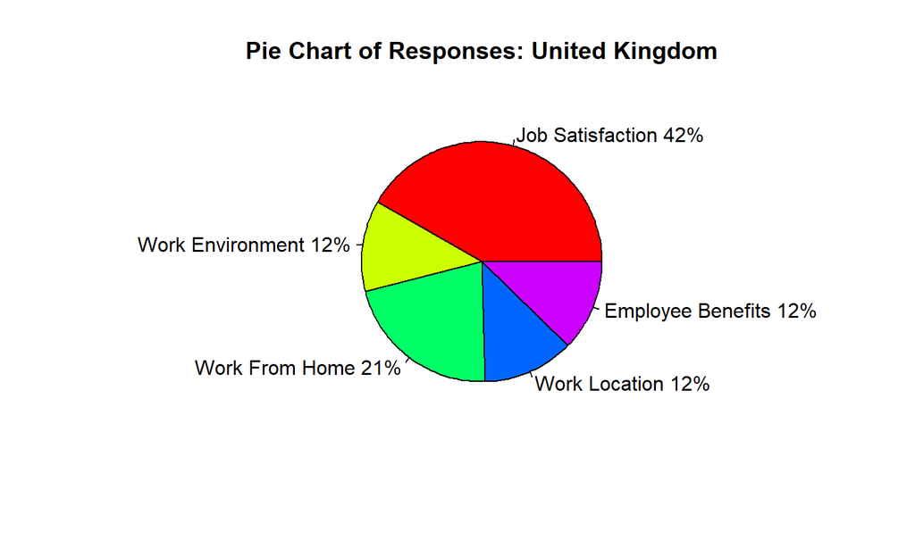

```
## [1] "Total Responses:  252"
```

## USA Results

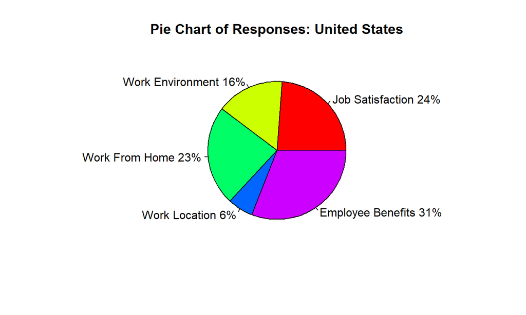

```
## [1] "Total Responses:  252"
```

## USA Western Region Results

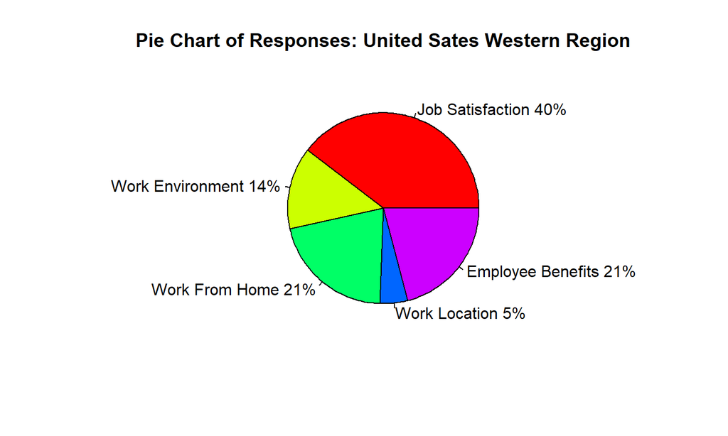

```
## [1] "Total Responses:  43"
```

## Total Results

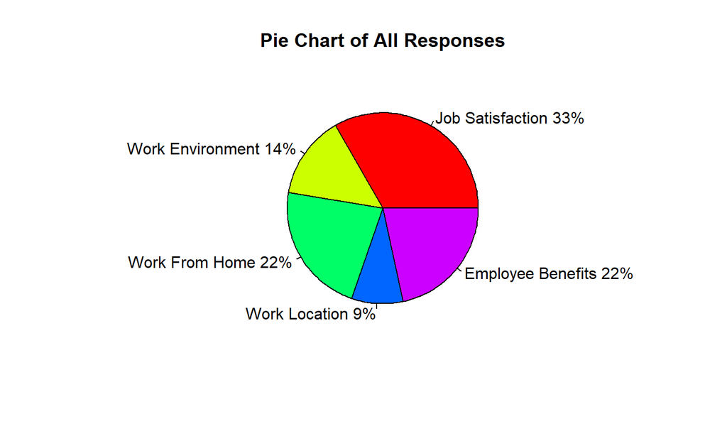

```
## [1] "Total Responses:  547"
```

## Normal Distribution UK

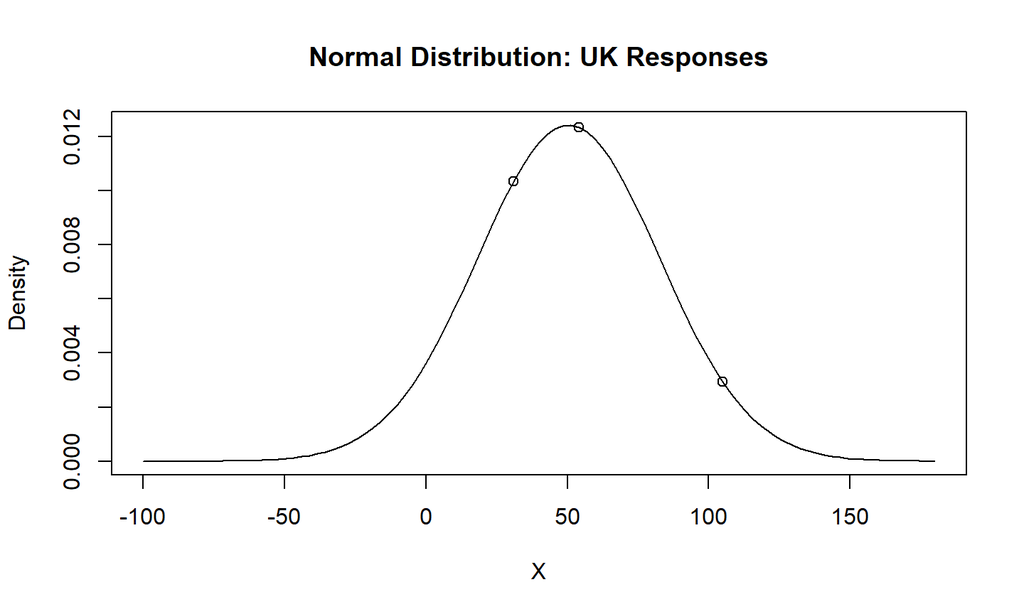

## Normal Distribution USA

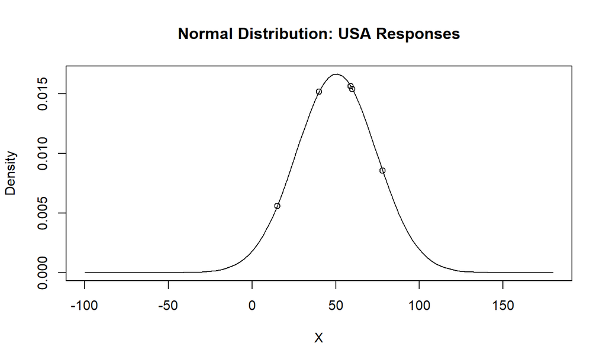

## Job Satisfaction

```
##
##  Exact binomial test
##
## data:  x and n
## number of successes = 182, number of trials = 547, p-value = 3.987e-15
## alternative hypothesis: true probability of success is not equal to 0.5
## 95 percent confidence interval:
##  0.2933190 0.3739479
## sample estimates:
## probability of success
##              0.3327239
```

## Work From Home

```
##
##  Exact binomial test
##
## data:  x and n
## number of successes = 122, number of trials = 547, p-value < 2.2e-16
## alternative hypothesis: true probability of success is not equal to 0.5
## 95 percent confidence interval:
##  0.1888108 0.2602820
## sample estimates:
## probability of success
##              0.2230347
```

## Employee Benefits

```
##
##  Exact binomial test
##
## data:  x and n
## number of successes = 118, number of trials = 547, p-value < 2.2e-16
## alternative hypothesis: true probability of success is not equal to 0.5
## 95 percent confidence interval:
##  0.1819521 0.2525965
## sample estimates:
## probability of success
##              0.2157221
```

## Limitations

- sample population is a very small subset of the general population.
- divide the general population by a large amount.
- larger sample population may have given us competently different results
- limited due to funding (I.E. It was expensive)

## Conclusions

The population tells us that people are leaning towards having great job satisfaction. This term can be broad, but the typical description is having a satisfying job. How does this correlate to a pandemic changing workers’ perception? This does not answer our question directly. It could be many different things that can cause someone to choose that option.